# Machine Learning

## Summary

This data used for this project is related to physical activity using measurements from accelerometers on the belt, forearm, arm, and dumbell of 6 participants. A suitable model was built using the training dataset to predict the manner in which the exercise was done (represented by the `classe` variable in the dataset).

### Getting and cleaning data

The training and testing data sets were downloaded from the URLs.

```r
train_data <- read.csv("https://d396qusza40orc.cloudfront.net/predmachlearn/pml-training.csv")
test_data <- read.csv("https://d396qusza40orc.cloudfront.net/predmachlearn/pml-testing.csv")
dim(train_data)
```

```
## [1] 19622   160
```

```r
dim(test_data)
```

```
## [1]  20 160
```

The dataset was processed to select the predictors to be used in the model.

The non-numeric variables (columns 1-8) giving information such as that of the subject and time of activity were removed from the set.

```r
train_data <- train_data[,-c(1:8)]
test_data <- test_data[,-c(1:8)]
```

Next, the variables with near zero variance were identified and removed.

```r
library(caret)
nz<-nearZeroVar(train_data)
train_data<-train_data[,-nz]
test_data<-test_data[,-nz]
```

Several variables were found to have a high proportion of missing (NA) values. The variables with more than 90% missing values were removed.

```r
na_col <- sapply(train_data, function(x) mean(is.na(x))>0.9)
train_fin <- train_data[,na_col==FALSE]
test_fin<-test_data[,na_col==FALSE]
```

The training set was split into a training set for building the model and a validation set to test the accuracy of the models.

```r
set.seed(1223)
inTrain <- createDataPartition(train_fin$classe,p=0.6,list=FALSE)
training <- train_fin[inTrain,]
val <- train_fin[-inTrain,]
```

## Building the prediction model

1. Decision tree (CART)

```r
library(rattle)
```

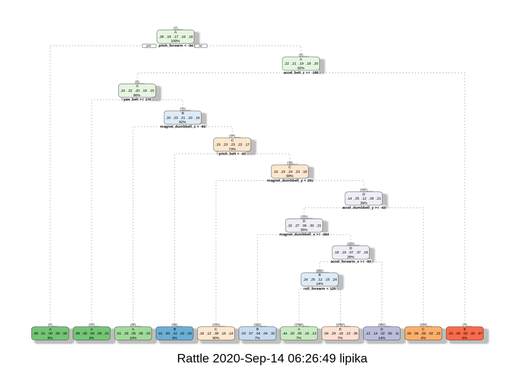

```r
fit_dt <- train(classe~.,data=training,method="rpart")
fancyRpartPlot(fit_dt$finalModel)
```

The accuracy was tested on the validation set to assess the out-of-sample error.

```r
tab_dt <- confusionMatrix(predict(fit_dt,val),val$classe)
tab_dt
```

```
## Confusion Matrix and Statistics
##
##           Reference
## Prediction    A    B    C    D    E
##          A 1555  382   60  159   69
##          B   35  565   46   32  216
##          C  452  267 1134  387  394
##          D  153  161   36  645  150
##          E   37  143   92   63  613
##
## Overall Statistics
##
##                Accuracy : 0.5751
##                  95% CI : (0.564, 0.586)
##     No Information Rate : 0.2845
##     P-Value [Acc > NIR] : < 2.2e-16
##
##                   Kappa : 0.4639
##
##  Mcnemar's Test P-Value : < 2.2e-16
##
## Statistics by Class:
##
##                      Class: A Class: B Class: C Class: D Class: E
## Sensitivity            0.6967  0.37220   0.8289  0.50156  0.42510
## Specificity            0.8807  0.94801   0.7684  0.92378  0.94769
## Pos Pred Value         0.6989  0.63199   0.4305  0.56332  0.64662
## Neg Pred Value         0.8796  0.86292   0.9551  0.90434  0.87982
## Prevalence             0.2845  0.19347   0.1744  0.16391  0.18379
## Detection Rate         0.1982  0.07201   0.1445  0.08221  0.07813
## Detection Prevalence   0.2836  0.11394   0.3357  0.14593  0.12083
## Balanced Accuracy      0.7887  0.66010   0.7987  0.71267  0.68640
```

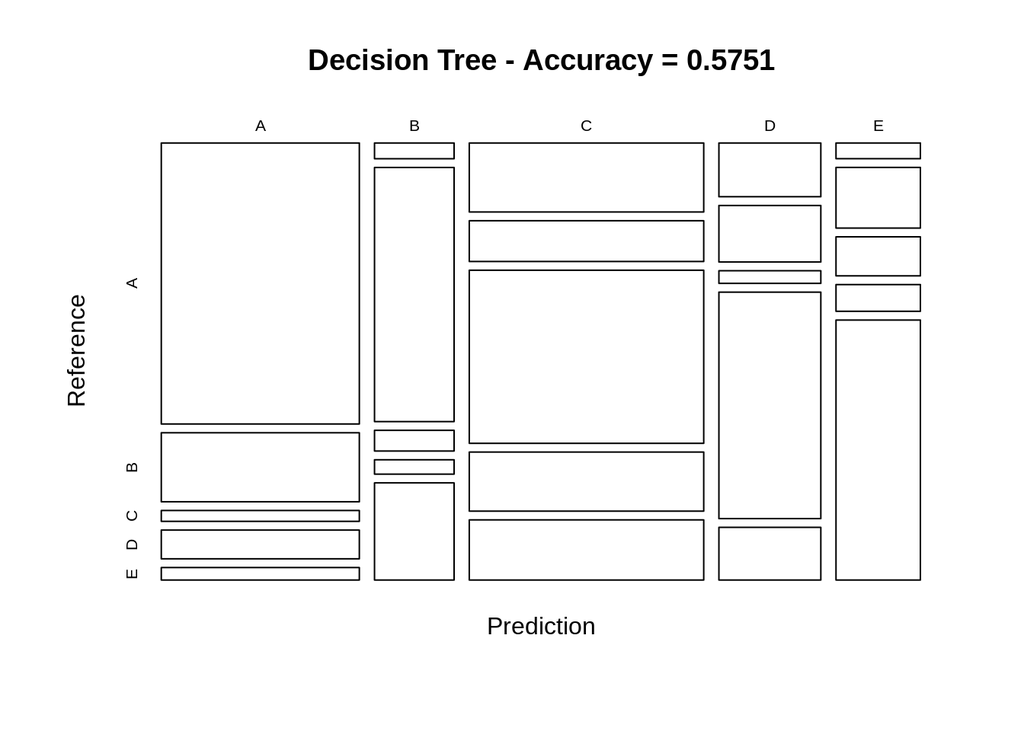

```r
plot(tab_dt$table,col=tab_dt$byClass,main=paste("Decision Tree - Accuracy =",round(tab_dt$overall['Accuracy'],4)))
```

The accuracy of the model was about `57.51`% which is quite low. Other models were tried to increase the accuracy.

2. Random Forest

```r
fit_rf <- train(classe~.,data=training,method="rf",ntree=100)
tab_rf <- confusionMatrix(predict(fit_rf,val),val$classe)
tab_rf
```

```
## Confusion Matrix and Statistics
##
##           Reference
## Prediction    A    B    C    D    E
##          A 2230   17    0    0    0
##          B    2 1494    3    0    1
##          C    0    6 1362   19    3
##          D    0    0    3 1265    5
##          E    0    1    0    2 1433
##
## Overall Statistics
##
##                Accuracy : 0.9921
##                  95% CI : (0.9899, 0.9939)
##     No Information Rate : 0.2845
##     P-Value [Acc > NIR] : < 2.2e-16
##
##                   Kappa : 0.99
##
##  Mcnemar's Test P-Value : NA
##
## Statistics by Class:
##
##                      Class: A Class: B Class: C Class: D Class: E
## Sensitivity            0.9991   0.9842   0.9956   0.9837   0.9938
## Specificity            0.9970   0.9991   0.9957   0.9988   0.9995
## Pos Pred Value         0.9924   0.9960   0.9799   0.9937   0.9979
## Neg Pred Value         0.9996   0.9962   0.9991   0.9968   0.9986
## Prevalence             0.2845   0.1935   0.1744   0.1639   0.1838
## Detection Rate         0.2842   0.1904   0.1736   0.1612   0.1826
## Detection Prevalence   0.2864   0.1912   0.1772   0.1622   0.1830
## Balanced Accuracy      0.9980   0.9916   0.9956   0.9912   0.9966
```

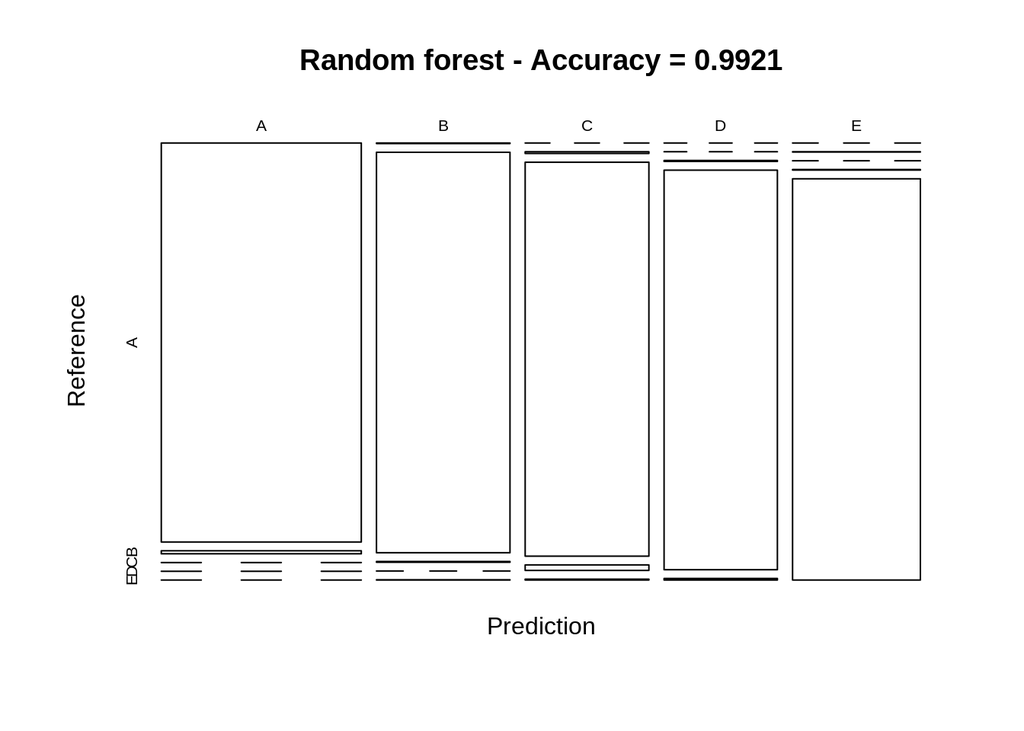

```r
plot(tab_rf$table,col=tab_rf$byClass,main=paste("Random forest - Accuracy =",round(tab_rf$overall['Accuracy'],4)))
```

The accuracy of the model was about `99.21`%. Since this accuracy was high, the random forest model was selected.

### Final prediction - predicting classe for test data set

```r
predict(fit_rf,test_fin)
```

```
##  [1] B A B A A E D B A A B C B A E E A B B B
## Levels: A B C D E
```